# Human Activity Recognition Project

Massimo Morelli

Wednesday, June 18, 2014

## Summary

In this report I try to train a machine learning model to predict the activity of the subject in a HAR (Human Activity Recognition) exercise. HAR is a growing field of research, which tries to understand Human Behavior from observations regarding the subject and its environment. With a Random Forest predictor the Accuracy of 97% is reached, even with limited computing resource.

## Method

### Data collection

```r
library(caret)
```

```r
library(ggplot2)
dat <-   read.csv("..\\data\\pml-training.csv", na.strings= c("NA", "#DIV/0!"))
proof <- read.csv("..\\data\\pml-testing.csv",  na.strings= c("NA", "#DIV/0!"))
```

### Exploratory analysis

Data are loaded in a data frame. There are 160 features, and many of them have a great proportion of NA. There appear to be a strong collinearity in many of the variables, so some kind of dimension reduction appears mandatory.

I divided the training data in three set: training, test, validation, to be used to training the model, to test various models, to predict out of sample accuracy.

Due to the scarce computing resource at my disposal I kept the first train set extremely small. Once the model was chosen I could retrain it with more data.

```r
# divide test and training
# Create a building data set and validation set
set.seed(7)
inBuild <- createDataPartition(y=dat$classe,  p=0.7, list=FALSE)
validation <- dat[-inBuild,];
buildData <- dat[inBuild,]

# Intern data test divide in train and test. For performance reason we keep
# the train set extremely small
set.seed(11)
small <- createDataPartition(y=buildData$classe,  p=0.1, list=FALSE)
train.small <- buildData[small,]
testing     <- buildData[-small,]
dim(train.small)
```

```
## [1] 1376  160
```

```r
dim(testing)
```

```
## [1] 12361   160
```

Some column appear to be related to the experiment (windows variable, timestam variable, X) and even if in the preliminary analysis performed they seems to be very helpful in predict the variable of interest, I don’t think that would be fair to introduce them in the analysis, so I excluded them. As an example of this fact see in the following figure as the “classe” variable is visually correlated with X:

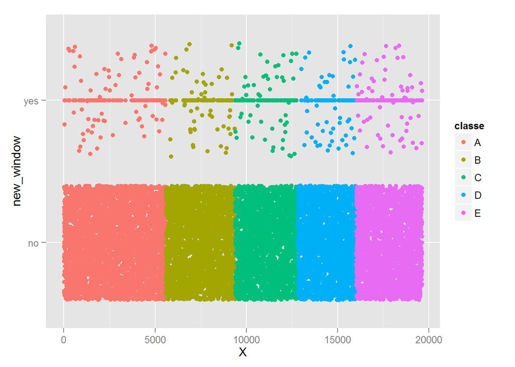

```r
# eliminate columns relative to the experiment
colElim <- c("X" , "user_name", "raw_timestamp_part_1", "raw_timestamp_part_2",
             "new_window", "num_window", "cvtd_timestamp")
colConserv <- setdiff(names(train.small), colElim)
train.small <- subset(train.small, T, colConserv)

# ------------ real feature selection --------------------------------------
# pre process: eliminate the near zero variance variable
nzv <- nearZeroVar(train.small)
train.small <- train.small[, -nzv]
dim(train.small)
```

```
## [1] 1376  144
```

```r
# save classe
classe <- train.small$classe
#train.small <- train.small[, -c("X")]

# eliminate non numeric
sa <- sapply(train.small, is.numeric )
train.small <- train.small[,-which(sa==F)]

#  eliminate the non correlable
train.small <- train.small[, -which(is.na(cor(train.small)))]
descrCorr <- cor(train.small)

#  eliminate the high correlate
highCorr <- findCorrelation(descrCorr, 0.9)
train.small <- train.small[, -highCorr]

# set the predicted
train.small$classe <- classe
dim(train.small)
```

```
## [1] 1376   48
```

```r
# save features
names <- names(train.small)
```

## Statistical modeling

```r
RERUN=FALSE
if(RERUN){
    set.seed(13)
    modRf <- train(classe ~ . , data=train.small, trControl = ctrl, method="rf",  prox=T, number=5)
    save(modRf, file = "..\\data\\my_model.rda")
} else{load("..\\data\\my_model.rda")}
# varImp(modRf) # relative importance of predictors
# predict
predRf <- predict(modRf,testing);
matrixRf <- confusionMatrix(predRf, testing$classe)
# accuracy
matrixRf$overall[1]
```

```
## Accuracy
##   0.9155
```

```r
#-----------------------------------------------------------------------------
# test with other models : Penalized Multinomial Regression
modLDA <- train(classe ~ . , data=train.small, method="PenalizedLDA")
predLDA <- predict(modLDA,testing);
matrixLDA <- confusionMatrix(predLDA, testing$classe)
# accuracy
matrixLDA$overall[1]
```

```
## Accuracy
##    0.451
```

```r
# pda: penalized discriminant analysis
modPda <- train(classe ~ . , data=train.small, method="pda")
predPda <- predict(modPda,testing);
matrixPda <- confusionMatrix(predPda, testing$classe)
# accuracy
matrixPda$overall[1]
```

```
## Accuracy
##   0.6694
```

```r
#-----------------------------------------------------------------------------
```

A New Random Forest model has then been trained with more data, but unfortunately with my PC I could not use all of them. Using 30% of the train/test data I obtained a more accurate model that I k-mean cross-validated with the help of the Caret package. Of course the model would be even more accurate with more data. This would be easy to check, having access to a more powerful computer.

```r
# retrain with more data
set.seed(13)
getTrain   <- createDataPartition(y=buildData$classe,  p=0.3, list=FALSE)
train       <- buildData[getTrain,]
testing     <- buildData[-getTrain,]

# filter the feature
train <- subset(train, T, names)

RERUN=FALSE
if(RERUN){
    set.seed(13)
    ctrl <- trainControl(method = "cv", repeats = 4)
    modRf_Fin <- train(classe ~ . , data=train, trControl = ctrl, method="rf",  prox=T, number=5)
    save(modRf_Fin, file = "..\\data\\my_model_final.rda")
} else{load("..\\data\\my_model_final.rda")}
predRf <- predict(modRf_Fin,testing);
matrixRf_Fin <- confusionMatrix(predRf, testing$classe)
matrixRf_Fin$overall[1]
```

```
## Accuracy
##   0.9687
```

The final model hat 97% accuracy on the test set.

Now that the model is chosen, cross-validated and trained it is possible to estimate the **out of sample performance** using the validation data that were spared until now.

```r
# check our resulting model over the validation set
predRfVal <- predict(modRf_Fin,validation);
matrixRfVal <- confusionMatrix(predRfVal, validation$classe)
matrixRfVal$overall[1]
```

```
## Accuracy
##   0.9703
```

The (out of sample) validation performance is also 97%.

The confusion matrix obtained is the following:

```r
matrixRfVal$table
```

```
##           Reference
## Prediction    A    B    C    D    E
##          A 1659   29    0    0    0
##          B    9 1087   39    4    8
##          C    2   21  975   25    4
##          D    4    2    9  932   13
##          E    0    0    3    3 1057
```

## Reproducibility

All analyses performed in this manuscript are reproduced in the R markdown file HAR_Finale.Rmd [5]

## Bibliography

[1] Velloso, E.; Bulling, A.; Gellersen, H.; Ugulino, W.; Fuks, H. Qualitative Activity Recognition of Weight Lifting Exercises. Proceedings of 4th International Conference in Cooperation with SIGCHI (Augmented Human ’13) . Stuttgart, Germany: ACM SIGCHI, 2013.

[2] Colby, S, Lee, S, Lewinger, JP, Bull, S. Pmlr: Penalized Multinomial Logistic Regression. R package version 1.0; 2010. http://cran.r-project.org/web/packages/pmlr/pmlr.pdf

[3] Hastie, Trevor; Buja, Andreas; Tibshirani, Robert. Penalized Discriminant Analysis. The Annals of Statistics 23 (1995), no. 1, 73–102. doi:10.1214/aos/1176324456. http://projecteuclid.org/euclid.aos/1176324456. http://www.stanford.edu/~hastie/Papers/pda.pdf

[4] A. Liaw and M. Wiener (2002). Classification and Regression by randomForest. R News 2(3), 18–22. http://cran.r-project.org/web/packages/pmlr/pmlr.pdf

[5] R Markdown Page. URL: http://www.rstudio.com/ide/docs/authoring/using_markdown. Accessed 18.06.2014